# Objects and Functions

Basel R Bootcamp, July 2018 [www.therbootcamp.com](https://therbootcamp.github.io) [@therbootcamp](https://twitter.com/therbootcamp)

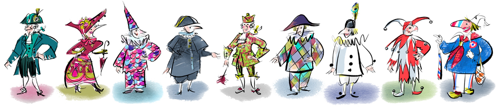

https://www.baslerfasnacht.info/basel-fasnacht/index.php

### Overview

In this practical you’ll learn how to work with simple data objects and functions. By the end of this practical you will know how to:

1. Create vectors of different types using `c()`
2. Understand the three main vector classes numeric, character, and logical using `class()`
3. Create `data.frames` and `tibbles`! using `data.frame()` and `tibble()`
4. Access vectors from data frames using `$`
5. Calculate basic descriptive statistics using `mean()`, `median()`, `table()` (and more!)

### Datasets

*None!*

### Packages

| Package | Installation |
| --- | --- |
| `tidyverse` | `install.packages("tidyverse")` |

### Glossary

*Creating vectors*

| Function | Description |
| --- | --- |
| `c("a", "b", "c")` | Create a character vector |
| `c(1, 2, 3)` | Create a numeric vector |
| `c(TRUE, FALSE, TRUE)` | Create a logical vector |

*Vector functions*

| Function | Description |
| --- | --- |
| `mean(x), median(x), sd(x), sum(x)` | Mean, median standard deviation, sum |
| `max(x), min(x)` | Maximum, minimum |
| `table(x)` | Table of frequency counts |
| `round(x, digits)` | Round a numeric vector x to `digits` |

*Creating data frames from vectors*

| Function | Description |
| --- | --- |
| `data.frame(a, b, c)` | Create a data frame from vectors a, b, c |
| `tibble(a, b, c)` | Create a tibble from vectors a, b, c |

*Accessing vectors from data frames*

| Function | Description |
| --- | --- |
| `df$name` | Access vector `name` from a data frame `df` |

### Examples

```r
library(tidyverse)

# Create vectors of (fake) stock data
name      <- c("apple", "microsoft", "dell", "google", "twitter")
yesterday <- c(100, 89, 65, 54, 89)
today     <- c(102, 85, 72, 60, 95)

# Summary statistics
mean(today)
mean(yesterday)

# Show classes
class(name)
class(yesterday)

# Operations of vectors
change <- today - yesterday
change # Print result

# Create a logical vector from two numerics
increase <- today > yesterday
increase # Print result

# Create a tibble combining multiple vectors
stocks <- tibble(name, yesterday, today, change, increase)

# Get column names
names(stocks)

# Access columns by name
stocks$name
stocks$today

# Calculate descriptives on columns
mean(stocks$yesterday)
median(stocks$today)
table(stocks$increase)
max(stocks$increase)
```

# Tasks

## A - Getting setup

1. Open your `baselrbootcamp` R project. It should already have the folders `1_Data` and `2_Code`.
2. Open a new R script and save it as a new file called `objects_practical.R` in the `2_Code` folder. At the top of the script, using comments, write your name and the date. Then, load all package(s) listed in the Packages section above with `library()`.

## B - Creating vectors

The table below shows results from a (fictional) survey of 10 Baselers. In this practical, you will convert this table to R objects and then analyse them!

| id | sex | age | height | weight |
| --- | --- | --- | --- | --- |
| 1 | male | 44 | 174.3 | 113.4 |
| 2 | male | 65 | 180.3 | 75.2 |
| 3 | female | 31 | 168.3 | 55.5 |
| 4 | male | 27 | 209 | 93.8 |
| 5 | male | 24 | 176.7 |  |
| 6 | male | 63 | 186.6 | 67.4 |
| 7 | male | 71 | 151.6 | 83.3 |
| 8 | female | 41 | 155.7 | 67.8 |
| 9 | male | 43 | 176.1 | 69.3 |
| 10 | female | 31 | 166.1 | 66.3 |

1. Create a numeric vector called `id` that shows the id values. When you finish, print the vector object to see it!

```r
# Create a vector id
XX <- c(XX, XX, ...)

# Print the vector id
XX
```

```r
# Create an id vector
id <- 1:10 # shortcut to creating the sequence from 1 to 10

# Print the vector
id
```

```
##  [1]  1  2  3  4  5  6  7  8  9 10
```

2. Using the `class()` function, check the class of your `id` vector. Is it `"numeric"`?

```r
# Show the class of an object XX
class(XX)
```

```r
# Show the class of the id vector
class(id)
```

```
## [1] "integer"
```

3. Using the `length()` function, find out the length of your `id` vector. Does it have length 10? If not, make sure you defined it correctly!

```r
# Show the length of the id vector
length(XX)
```

```r
# Show the length of the id vector
length(id)
```

```
## [1] 10
```

4. Create a character vector called `sex` that shows the sex values. Make sure to use quotation marks “” to enclose each element to tell R that the data are of type `"character"`! When you finish, print the object to see it!

```r
# Create a character vector sex
XX <- c("XX", "XX", "...")
```

```r
# Create a sex vector
sex <- c("male", "male", "female", "male", "male", "male", "male", "female", "male", "female")

# Print the vector
sex
```

```
##  [1] "male"   "male"   "female" "male"   "male"   "male"   "male"
##  [8] "female" "male"   "female"
```

5. Using the `class()` function, check the class of your `sex` vector. Is it `"character"`?

```r
# Show the class of the sex vector
class(sex)
```

```
## [1] "character"
```

6. Using the `length()` function, find out the length of your `sex` object. Does it have length 10? If not, make sure you defined it correctly!

```r
# Show the length of the sex vector
length(sex)
```

```
## [1] 10
```

7. Using the same steps as before, create a `age` and `height` vector.

```r
# Create a age vector
age <- c(44, 65, 31, 27, 24, 63, 71, 41, 43, 31)

# Print the age vector
age
```

```
##  [1] 44 65 31 27 24 63 71 41 43 31
```

```r
# Show the class of the age vector
class(age)
```

```
## [1] "numeric"
```

```r
# Show the length of the age vector
length(age)
```

```
## [1] 10
```

```r
# Create a height vector
height <- c(174.3, 180.3, 168.3, 209, 176.7, 186.6, 151.6, 155.7, 176.1, 166.1)

# Print the height vector
height
```

```
##  [1] 174 180 168 209 177 187 152 156 176 166
```

```r
# Show the class of the height vector
class(height)
```

```
## [1] "numeric"
```

```r
# Show the length of the height vector
length(height)
```

```
## [1] 10
```

8. Look at the weight data, you’ll notice it contains an missing value. Create a vector called `weight` containing these data, following the same steps as before, making sure to specify the missing value as `NA` (no quotation marks).

```r
# Create a weight vector
weight <- c(113.4, 75.2, 55.5, 93.8, NA, 67.4, 83.3, 67.8, 69.3, 66.3)

# Print the weight vector
weight
```

```
##  [1] 113.4  75.2  55.5  93.8    NA  67.4  83.3  67.8  69.3  66.3
```

```r
# Show the class of the weight vector
class(weight)
```

```
## [1] "numeric"
```

```r
# Show the length of the weight vector
length(weight)
```

```
## [1] 10
```

## C - Functions

1. Using the `table()` function, find out how many males and females are in the data. You should find 7 males and 3 females!

```r
# Count types in sex
table(sex)
```

```
## sex
## female   male
##      3      7
```

2. Using the `mean()` function, calculate the mean `age`. It should be 44!

```r
# Compute mean of age
mean(age)
```

```
## [1] 44
```

3. Try calculating the mean value of `sex`. What happens? Why?

```r
# Compute mean of sex
mean(sex)
```

```
## [1] NA
```

4. Try calculating the mean `weight`. You should get an `NA` value. Why?

```r
# Compute mean of sex
mean(weight)
```

```
## [1] NA
```

5. Look at the help menu for the `mean()` function (using `?mean`) to look for an argument that will help you with your problem.

```r
# Inspect help for mean
?mean
```

6. Using the correct argument for the mean function, calculate the mean weight ignoring `NA` values. It should be 76.89!

```r
# Compute mean weight, ignoring NAs
mean(weight, na.rm = TRUE)
```

```
## [1] 76.9
```

## D - Logical Vectors

1. Logical vectors contain only `TRUE` and `FALSE` values (and missing values). Create a new vector called `tall_180` indicating which Baselers are taller than 180cm. To do this, use the `>` (greater than) operator á la `vector > value`.

```r
# Create a logical vector tall_180 indicating
#  which baselers are taller than 180cm

XX <- XX > XX
```

```r
# Create a logical vector tall_180
tall_180 <- height > 180
```

```r
# print tall
tall_180
```

```
##  [1] FALSE  TRUE FALSE  TRUE FALSE  TRUE FALSE FALSE FALSE FALSE
```

3. Using the `table()` function, create a table showing how many of the ten Baselers are taller than 180cm and how many are not

```r
# count baselers taller than 180
table(tall_180)
```

```
## tall_180
## FALSE  TRUE
##     7     3
```

4. Using the `mean()` function, determine the percentage of the ten Baselers that are taller than 180cm, i.e., `mean(tall_180)`. Should this have worked?

```r
# percentage of baselers taller than 180
mean(tall_180)
```

```
## [1] 0.3
```

5. What percent of the ten Baselers were older than 30?

```r
# percentage of baselers older than 30
mean(age > 30)
```

```
## [1] 0.8
```

## E - Creating data frames

1. Using the `data.frame()` function, create a data frame called `ten_df` that contains each of vectors you just created: `id`, `age`, `sex`, `height`, `weight`, `tall_180`

```r
# Create data frame ten_df containing vectors id, age, sex, height, weight, and tall_180
XX <- data.frame(XX, XX, XX, XX, XX, XX)
```

```r
# Create ten_df data frame from vectors
ten_df <- data.frame(id, age, sex, height, weight, tall_180)
```

2. Print your `ten_df` object to see how it looks! Does it contain all of the vectors?

```r
# Print ten_df
ten_df
```

```
##    id age    sex height weight tall_180
## 1   1  44   male    174  113.4    FALSE
## 2   2  65   male    180   75.2     TRUE
## 3   3  31 female    168   55.5    FALSE
## 4   4  27   male    209   93.8     TRUE
## 5   5  24   male    177     NA    FALSE
## 6   6  63   male    187   67.4     TRUE
## 7   7  71   male    152   83.3    FALSE
## 8   8  41 female    156   67.8    FALSE
## 9   9  43   male    176   69.3    FALSE
## 10 10  31 female    166   66.3    FALSE
```

```r
# Inspect dimensions
dim(ten_df)
```

```
## [1] 10  6
```

4. What is the class of your `ten_df` object? Use the `class()` function to find out!

```r
# Inspect class
class(ten_df)
```

```
## [1] "data.frame"
```

5. Use the `summary()` function to print descriptive statistics from each column of `ten_df`

```r
# Inspect class
summary(ten_df)
```

```
##        id             age           sex        height        weight
##  Min.   : 1.00   Min.   :24.0   female:3   Min.   :152   Min.   : 55.5
##  1st Qu.: 3.25   1st Qu.:31.0   male  :7   1st Qu.:167   1st Qu.: 67.4
##  Median : 5.50   Median :42.0              Median :175   Median : 69.3
##  Mean   : 5.50   Mean   :44.0              Mean   :174   Mean   : 76.9
##  3rd Qu.: 7.75   3rd Qu.:58.2              3rd Qu.:179   3rd Qu.: 83.3
##  Max.   :10.00   Max.   :71.0              Max.   :209   Max.   :113.4
##                                                          NA's   :1
##   tall_180
##  Mode :logical
##  FALSE:7
##  TRUE :3
##
##
##
##
```

6. Using the `$` operator, print the `age` column from the `ten_df` data frame.

```r
# Inspect age
ten_df$age
```

```
##  [1] 44 65 31 27 24 63 71 41 43 31
```

7. Calculate the maximum `age` value from the `ten_df` data frame using `max()`. Do you get the same result from when you calculated it from the original vector `age`?

```r
# Get max
max(ten_df$age)
```

```
## [1] 71
```

8. Instead of creating a data frame of the data using the `data.frame()` function, try creating a tibble called `ten_tibble` using the `tibble()` function. `tibble`s are a more modern, leaner variant of data frame that we prefer over classic `data.frame`s You can use the exact same arguments you used before.

```r
# create tibble
ten_tibble = tibble(id, sex, height, weight, tall_180)
```

9. Print your new `ten_tibble` object, how does it look different from `ten_df`? Try calculating the maximum `age` from this object. Is it different from what you got before?

```r
# print tibble
ten_tibble
```

```
## # A tibble: 10 x 5
##       id sex    height weight tall_180
##    <int> <chr>   <dbl>  <dbl> <lgl>
##  1     1 male     174.  113.  FALSE
##  2     2 male     180.   75.2 TRUE
##  3     3 female   168.   55.5 FALSE
##  4     4 male     209    93.8 TRUE
##  5     5 male     177.   NA   FALSE
##  6     6 male     187.   67.4 TRUE
##  7     7 male     152.   83.3 FALSE
##  8     8 female   156.   67.8 FALSE
##  9     9 male     176.   69.3 FALSE
## 10    10 female   166.   66.3 FALSE
```

```r
max(ten_tibble$age) == max(ten_df$age)
```

```
## [1] FALSE
```

## X - Challenges

1. If you take the `sum()` of a logical vector, R will return the number of cases that are `TRUE`. Using this, find out how many of the ten Baselers are male while using the is-equal-to operator `==`.

```r
# Determine the frequency of a case in a vector
sum(XX == XX)
```

```r
# Determine the frequency of a case in a vector
sum(ten_tibble == "male")
```

```
## [1] NA
```

2. You can use logical vectors to select rows from a data frame based on certain criteria. using the following template, get the id values of Baselers who are younger than 30:

```r
# Create a logical vector indicating which baselers are younger than 30
young_30 <- XX$XX < 30

# Print the ids of baselers younger than 30
XX$XX[young_30]
```

```r
# Create a logical vector indicating which baselers are younger than 30
young_30 <- ten_tibble$age < 30

# Print the ids of baselers younger than 30
ten_tibble$id[young_30]
```

```
## integer(0)
```

3. Use a combination of logical vectors and the `mean()` function to answer the question: “What is the mean age of Baselers who are heavier than 80kg?”

```r
# Mean age of baselers heavier than 80kg
mean(ten_tibble$age[ten_tibble$weight > 80])
```

```
## [1] NA
```

4. What are the id values of Baselers who are male *and* are shorter than 165cm? (Hint: You will need to use the logical AND operator `&` to combine multiple logical vectors)

```r
# Mean age of baselers heavier than 80kg
ten_tibble$id[ten_tibble$sex == "male" & ten_tibble$height < 165]
```

```
## [1] 7
```

## Additional Resources

- For more information on the fundamentals of object and functions in R see the R Core team’s [introduction to R](https://cran.r-project.org/doc/manuals/r-release/R-intro.html) and for even more advanced object and function-related topics Hadley Wickham’s [Advanced R](http://adv-r.had.co.nz/).